# 6_LDA Speech

# 1 Introduction

- Using dataset https://data.gov.tw/dataset/42540

## 1.1 Process-of

1. Getting word tokens by `doc_term_count <- unnest()`
2. Building DocumentTermMatrix by `dtm <- tidytext::cast_dtm(doc_term_count, title, words, n)`
3. Getting word tokens by `word_token <- unnest()`
4. Building DocumentTermMatrix by `dtm <- tidytext::cast_dtm(word_token, title, words, n)`
5. Modeling by `dtm_lda <- topicmodels::LDA(dtm, k = 16, control = list(seed = 1234))`
6. Results
   1. Visualize word-topic probability by `dtm_topics <- tidy(dtm_lda, matrix = "beta")`
   2. Getting document-topic probability
   3. Building term network
7. Evaluation
   1. Calculating perplexity by different number of topics
   2. Evaluating by `library(ldatuning)`

# 2 Loading

```r
# install.packages("widyr")
# install.packages("topicmodels")
# install.packages("igraph")
# install.packages("ggraph")


library(tidyverse)
library(tidyr) # for unnest()
library(stringr)
library(jiebaR)
library(dplyr)
# " xcode-select --install"
# install.packages("http://download.r-forge.r-project.org/src/contrib/tmcn_0.2-9.tar.gz", repos = NULL, type = "source")
# library(tmcn)

# install.packages("devtools")
# devtools::install_github("qinwf/ropencc") # Convert S to Trad
browseURL("https://docs.google.com/presentation/d/e/2PACX-1vRTSSO_8JuLTK_1OyM9eDrogA-K2fhXQwlKxh1PpRvNavkurCCcKBNftv9MpKGYM6EDXtNnqZvPDdKy/pub?start=false&loop=false&delayms=3000&slide=id.g2c8ba90947_0_0")
browseURL("https://www.tidytextmining.com/ngrams.html")
```

# 3 Loading data

```r
# load("data/speech_data.RData")
#
# names(data_list) <- iconv(names(data_list), from="BIG5", to="UTF8")
# data_list$標題 <- iconv(data_list$標題, from="BIG5", to="UTF8")
# data_list <- data_list[-c(1,27),]
# # data_list$content <- iconv(data_list$content, from="BIG5", to="UTF8")
# data_list$content <- toTrad(data_list$content)
# docs$word <- NULL
#
# saveRDS(docs, "data/toChinaSpeech.rds")
# names(docs) <- c("title", "date", "link", "content", "word")
raw.df <- readRDS("data/toChinaSpeech.rds") %>%
    mutate(doc_id = row_number())
# data_list$word <- iconv(data_list$word, from="BIG5", to="UTF8")

# data_list$word <- sapply(data_list$word, function(x){iconv(x, from="BIG5", to="UTF8")})
```

# 4 Word segmentation

```r
library(jiebaR)
library(tidyr) # for unnest()
library(stringr)

cutter <- worker()
segment_not <- c("蔡英文", "南向政策", "副總統")
new_user_word(cutter, segment_not)
```

```
## [1] TRUE
```

```r
stopWords <- readRDS("data/stopWords.rds")

unnested.df <- raw.df %>%
    mutate(content = stringr::str_replace_all(content, "台灣", "臺灣")) %>%
    select(-link) %>%
    mutate(word = purrr::map(content, function(x)segment(x, cutter))) %>%
    unnest(word) %>%
    filter(!is.na(word)) %>%
    filter(!(word %in% stopWords$word)) %>%
    filter(!str_detect(word, "[a-zA-Z0-9]+"))
```

# 5 Tokenization

```r
doc_term_count <- unnested.df %>%
    count(title, word)
```

# 6 Term network

```r
library(widyr)
```

```r
word_pairs <- unnested.df %>%
    pairwise_count(word, title, sort = TRUE)

word_corr <- unnested.df %>%
    group_by(word) %>%
    filter(n() > 20) %>%
    pairwise_cor(word, title, sort = TRUE)
```

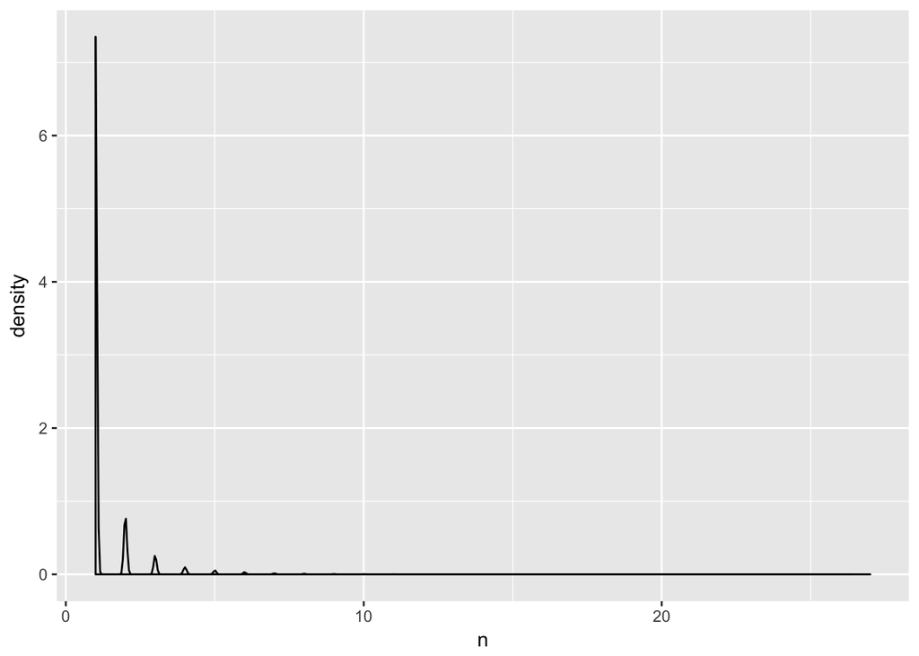

```r
library(igraph)
library(ggraph)
word_pairs %>%
    ggplot(aes(n)) +
    geom_density()
```

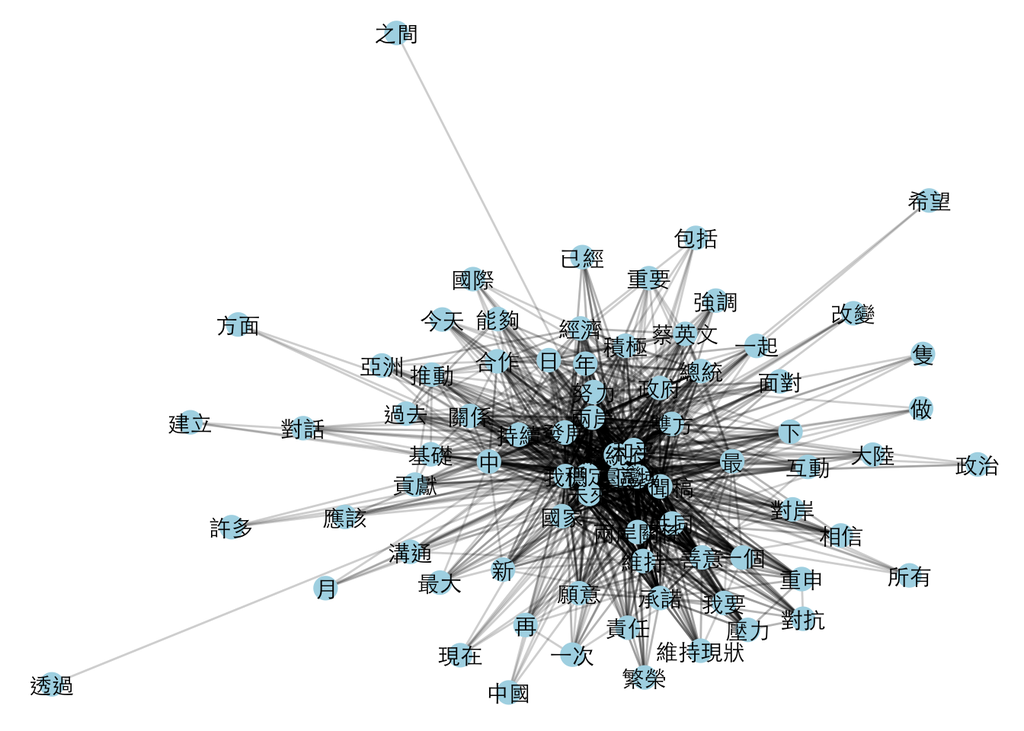

```r
set.seed(2016)
word_pairs %>%
  filter(n > 10) %>%
  graph_from_data_frame() %>%
  ggraph(layout = "fr") +
  geom_edge_link(aes(edge_alpha = n), show.legend = FALSE) +
  geom_node_point(color = "lightblue", size = 5) +
  geom_node_text(aes(label = name), repel = F, family = "Heiti TC Light") +
  theme_void()
```

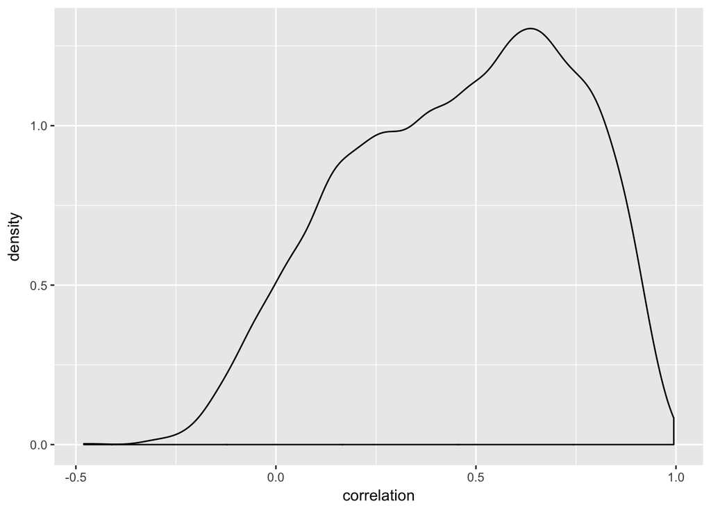

```r
word_corr %>%
    ggplot(aes(correlation)) +
    geom_density()
```

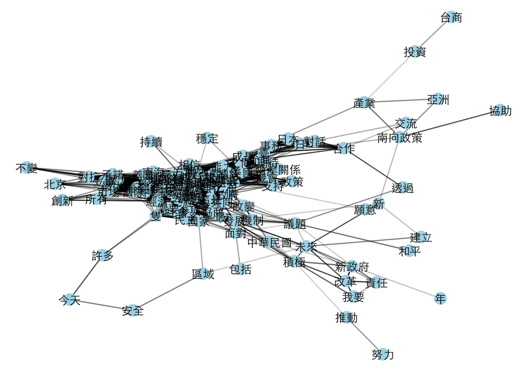

```r
set.seed(2016)
word_corr %>%
  filter(correlation > .75) %>%
  graph_from_data_frame() %>%
  ggraph(layout = "fr") +
  geom_edge_link(aes(edge_alpha = correlation), show.legend = FALSE) +
  geom_node_point(color = "lightblue", size = 5) +
  geom_node_text(aes(label = name), repel = F, family = "Heiti TC Light") +
  theme_void()
```

# 7 Building DocumentTermMatrix

```r
library(tidytext)
dtm <- cast_dtm(doc_term_count, title, word, n)
```

# 8 LDA

```r
library(topicmodels)
dtm_lda <- LDA(dtm, k = 16, control = list(seed = 1234))
dtm_lda4 <- LDA(dtm, k = 4, control = list(seed = 1234))
```

# 9 Word-topic probabilities

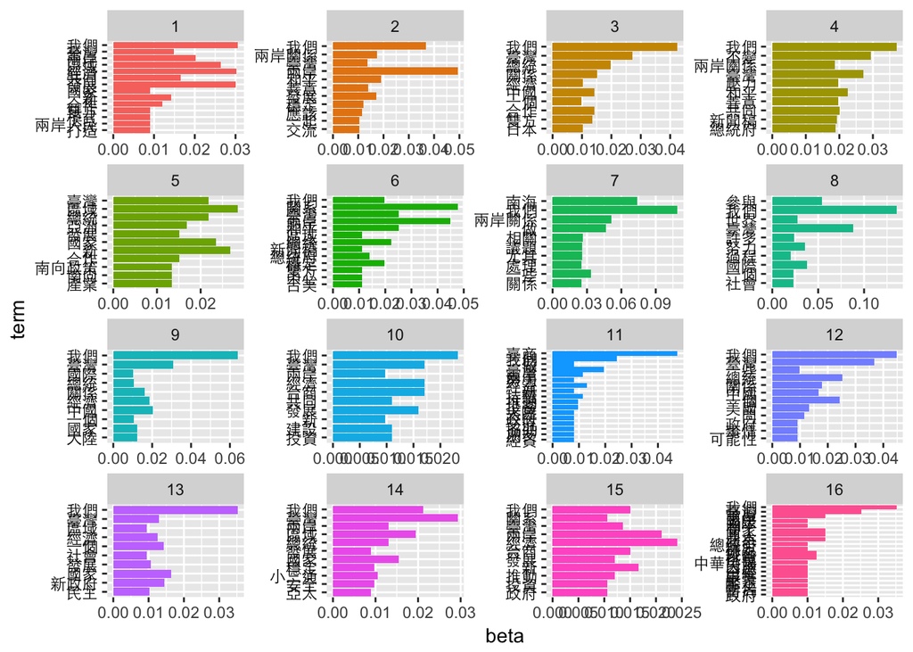

```r
library(ggplot2)
dtm_topics <- tidy(dtm_lda, matrix = "beta")

top_terms <- dtm_topics %>%
    group_by(topic) %>%
    top_n(10, beta) %>%
    ungroup() %>%
    arrange(topic, -beta)

# View(top_terms)

top_terms %>%
    mutate(term = reorder(term, beta)) %>%
    ggplot(aes(term, beta, fill = factor(topic))) +
    geom_col(show.legend = FALSE) +
    facet_wrap(~ topic, scales = "free") +
    coord_flip() +
    theme(axis.text.y=element_text(colour="black", family="Heiti TC Light"))
```

## 9.1 Comparing k=4

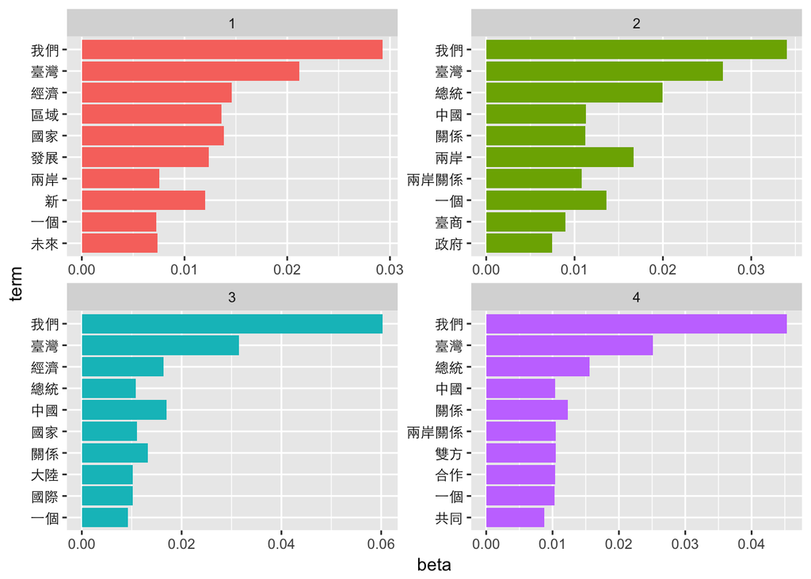

```r
dtm_topics_4 <- tidy(dtm_lda4)

top_terms_4 <- dtm_topics_4 %>%
    group_by(topic) %>%
    top_n(10, beta) %>%
    ungroup() %>%
    arrange(topic, -beta)
# View(top_terms_4)

top_terms_4 %>%
    mutate(term = reorder(term, beta)) %>%
    ggplot(aes(term, beta, fill = factor(topic))) +
    geom_col(show.legend = FALSE) +
    facet_wrap(~ topic, scales = "free") +
    coord_flip() +
    theme(axis.text.y=element_text(colour="black", family="Heiti TC Light"))
```